# Problem Set 8

Due date: 25 November

Please upload your completed assignment to the ELMs course site (under the assignments menu). Remember to include an annotated script file for all work with R and show your math for all other problems (if applicable, or necessary). Please also upload your completed assignment to the Github repository that you have shared with us. *We should be able to run your script with no errors.*

**Total points: 30**

```r
library(tidyverse)
library(skimr)
library(janitor)
library(ggsci)
library(MetBrewer)
library(devtools)
library(polisciols)
library(modelsummary)
library(readr)
library(broom)
library(infer)
library(scales)
```

## Question 1

*Points: 5*

For the following regression equation, $\hat{Y} = 8.5 + 6x + \epsilon$, the standard error for $\beta_0$ is 2.5, the standard error for $\beta_1$ is 3.5, and the sample size is 2000. Find the t-statistic, 95% confidence interval, and p-value (using a two-tailed test) for $\beta_1$.

Is $\beta_1$ statistically significant at the 0.05-level with a two-tailed test? Why or why not?

```r
t <- (6 - 0) / 3.5
t
```

```
[1] 1.714286
```

```r
6 + 1.96 * 3.5
```

```
[1] 12.86
```

```r
6 - 1.96 * 3.5
```

```
[1] -0.86
```

```r
2 * (1 - pt(abs(1.7143), 1998))
```

```
[1] 0.08662873
```

Answer: T-statistic is 1.714286, as df is 1998. The 95% confidence interval is (-0.86, 12.86), the p-value is 0.08662873. With this p-value, it is not statistically significant at the 0.05-level. And we cannot reject the null hypothesis.

## Question 2

*Points: 5*

Suppose you estimate an OLS regression and retrieve a $R^2$ value of 0.45. If the Total Sum of Squares (TSS) from that regression equals 4,700, what is the value for the Residual Sum of Squares (RSS)?

```r
R2 <- 0.45
TSS <- 4700

RSS <- (1 - R2) * TSS
RSS
```

```
[1] 2585
```

Answer: Since R^2 = 1 - RSS/TSS, we have RSS for 2585.

## Question 3

*Points: 5*

Suppose you estimate a bivariate regression with a sample size of 102 and obtain a regression coefficient ($\beta_1$) of 5.0. What is the largest standard error that $\beta_1$ could have and still be statistically significant (i.e., reject the null hypothesis of no relationship) at the 0.05 level with a one-tailed test?

```r
5.0 / 1.66
```

```
[1] 3.012048
```

Since we have a sample size of 102, the DF would be 102-1-1 = 100. With the one tailed test, the t for df = 100, level of 0.05 is 1.66. And the SE = $\beta_1$ / t, SE = 3.012048.

## Question 4

*Points: 5*

```r
gapminder_df <- wbstats::wb_data(c("NY.GDP.PCAP.CD", "SP.DYN.LE00.IN"),
                                 start_date = 2019, end_date = 2019) |>
  dplyr::rename(gdp_per_cap = "NY.GDP.PCAP.CD", life_exp = "SP.DYN.LE00.IN")
```

Using the `gapminder_df` data set read in above, produce a scatterplot of the variables `gdp_per_cap` and `life_exp` (with `life_exp` as the dependent variable on the y-axis). Fit a regression line to the scatterplot. Describe the relationship illustrated. Note any suspected outliers, if any (a visual inspection will suffice for this question).

**Note**

The variable `gdp_per_cap` measures each country’s GDP per capita (representing their individual wealth), and `life_exp` indicates the number of years individuals within that country born that year are expected to live (representing their health).

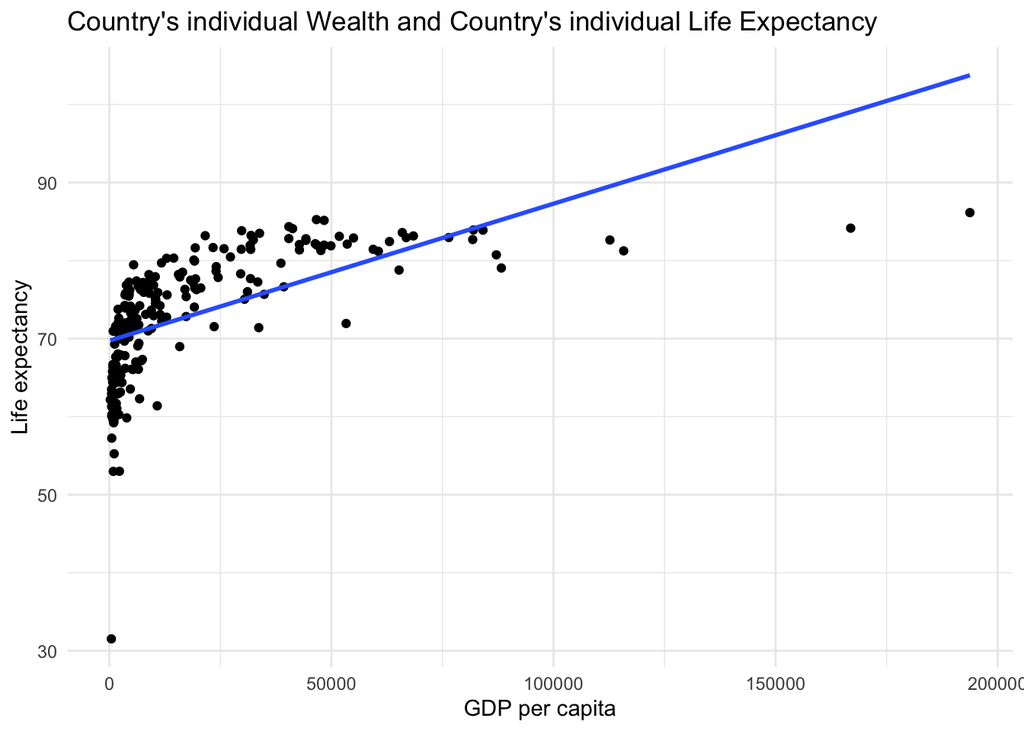

```r
ggplot(gapminder_df, aes(x = gdp_per_cap, y = life_exp)) +
  geom_point() +
  geom_smooth(method = "lm", se = F) +
  labs(x = "GDP per capita",
       y = "Life expectancy",
       title = "Country's individual Wealth and Country's individual Life Expectancy") +
  theme_minimal()
```

The scatterplot shows a positive but nonlinear relationship between GDP per capita and life expectancy. Countries with higher wealth tend to have longer life expectancy, but the gains diminish at high income levels. A few potential outliers are visible: one country with very low life expectancy(Central Africa), and several very wealthy countries(Such as Monaco and Liechtenstein) whose life expectancy is not unusually high. Despite these points, the overall pattern remains clearly upward sloping.

## Question 5

*Points: 10*

Estimate a bivariate regression with `life_exp` as the dependent variable and `gdp_per_cap` as the independent variable and report the results in a professionally formatted table. In as much detail as possible, describe (and interpret) the regression results.

```r
m <- lm(life_exp ~ gdp_per_cap, data = gapminder_df)
summary(m)
```

```
Call:
lm(formula = life_exp ~ gdp_per_cap, data = gapminder_df)

Residuals:
    Min      1Q  Median      3Q     Max
-38.288  -3.896   1.310   4.655   9.667

Coefficients:
             Estimate Std. Error t value Pr(>|t|)
(Intercept) 6.974e+01  5.370e-01  129.86   <2e-16 ***
gdp_per_cap 1.756e-04  1.608e-05   10.91   <2e-16 ***
---
Signif. codes:  0 '***' 0.001 '**' 0.01 '*' 0.05 '.' 0.1 ' ' 1

Residual standard error: 6.38 on 208 degrees of freedom
  (7 observations deleted due to missingness)
Multiple R-squared:  0.3642,    Adjusted R-squared:  0.3611
F-statistic: 119.1 on 1 and 208 DF,  p-value: < 2.2e-16
```

```r
modelsummary(m,
             coef_rename = c("gdp_per_cap" = "Level of Wealth"),
             statistic = c("conf.int", "p.value"))
```

|  | (1) |
| --- | --- |
| (Intercept) | 69.739 |
|  | [68.680, 70.797] |
|  | (<0.001) |
| Level of Wealth | 0.000 |
|  | [0.000, 0.000] |
|  | (<0.001) |
| Num.Obs. | 210 |
| R2 | 0.364 |
| R2 Adj. | 0.361 |
| AIC | 1378.3 |
| BIC | 1388.3 |
| Log.Lik. | -686.146 |
| RMSE | 6.35 |

1. The coefficient is positive and highly statistically significant, We can be confident that GDP per capita is positively associated with life expectancy. And Every 1 dollar increase in GDP per capita is associated with ~0.00018 additional years of life expectancy. So every $1000 increase in GDP per capita is associated with 0.18 additional years of life expectancy.
2. When Level of Wealth is equal to zero, the predicted value of the dependent variable is approximately 69.74. The confidence interval is very narrow, and the coefficient is highly statistically significant. estimated precisely. And for the level of Wealth, it is statistically significant but substantively negligible in its marginal effect.